# Tarea 1

### Actividades Propuestas

Nota: esta tarea no tiene evaluación

- Hacer lectura en la página del curso las siguientes publicaciones:
  - Código de Conducta
  - Programa
  - Plan de Evaluación
  - Recursos Disponibles
- Crear cuentas de usuario en:
  - https://login.posit.cloud/register
  - google - gmail. En caso de contar con una no es necesario crear una nueva.
- De la playlist https://www.youtube.com/playlist?list=PLkIselvEzpM6pZ76FD3NoCvvgkj_p-dE8 ver los videos
  - 1 **Case Study: Using Stents to Prevent Strokes**
  - 2 **Data Basics: Observations, Variable, and Data Matrices**

  Los vídeos se puede configurar para que sean traducidos de forma automática a español

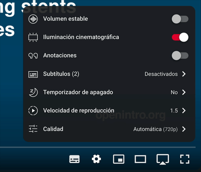

- Ver el vídeo “**Hans Rosling’s 200 Countries, 200 Years, 4 Minutes”** https://www.youtube.com/watch?v=jbkSRLYSojo&list=PLkIselvEzpM5nFf4nu--q2OGccA_0alYO
- Descarga del libro versión inglés (opcional): para aquellos que quieran tener la edición del texto en inglés que se usará a lo largo del curso, pueden acceder a la página https://leanpub.com/os . Pueden hacer el pago del libro o seleccionar en el *slider* “you pay” el monto cero, y proceder a realizar la descarga.
- Leer el texto de introducción a los jupyter notebooks en https://github.com/javendaXgh/ucveconomiaestadistica1/blob/main/notebooks/jupyter_intro.ipynb

### Lecturas recomendadas:

- Del libro Open Intro https://rpubs.com/javenda/openintroes , hasta la sección 1.3

Las actividades señaladas se sugiere cumplirlas antes del 27 de marzo.